# Citometry

Cytometry enable us to quantitatively measure cell concentration based on parameters like cell size, color, morphology and DNA content. This technology was developed in the field of human medicine and is now applied to marine sciences for microplankton counting and characterization. In this project, we classified cell types in three groups:

- Eukaryotic (size criteria): Nanoeukaryotes, and picoeukaryotes.
- Cyanobacteria (pigment criteria): *Prochlorococcus*, and *Synechococcus* genuses.
- DNA (content criteria): High nucleic acid (HNA), and low nucleic acid (LNA).

## 1 How much of each microplankton group was there?

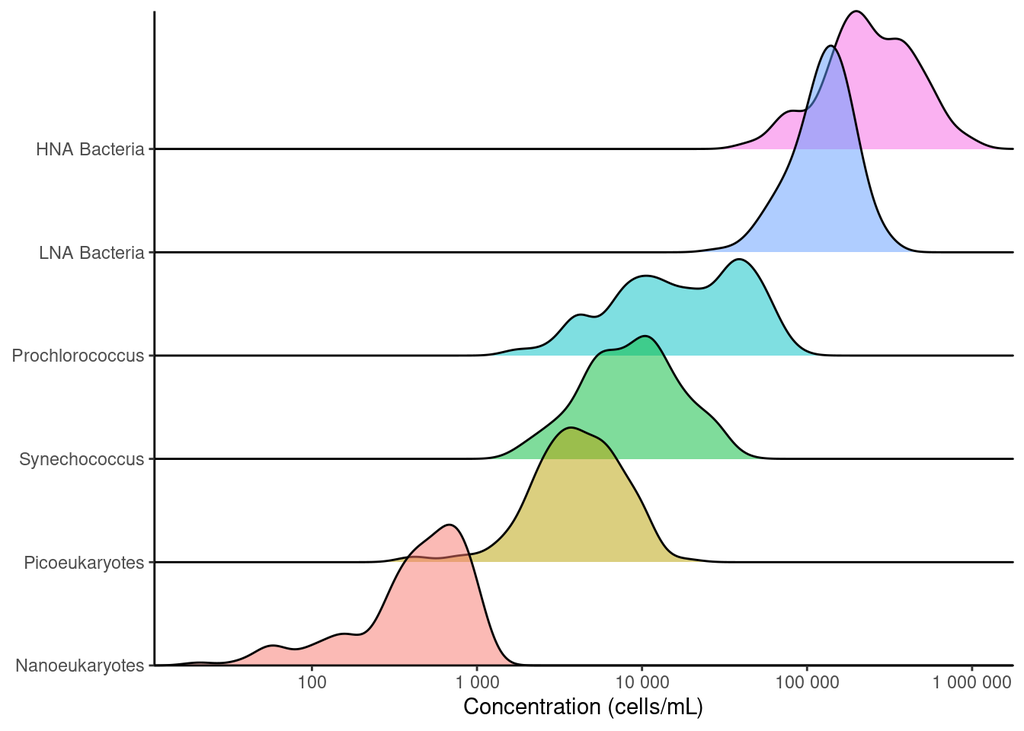

Figure 1: Density functions for all microplankton groups measured. Horizontal axis in logarithmic scale.

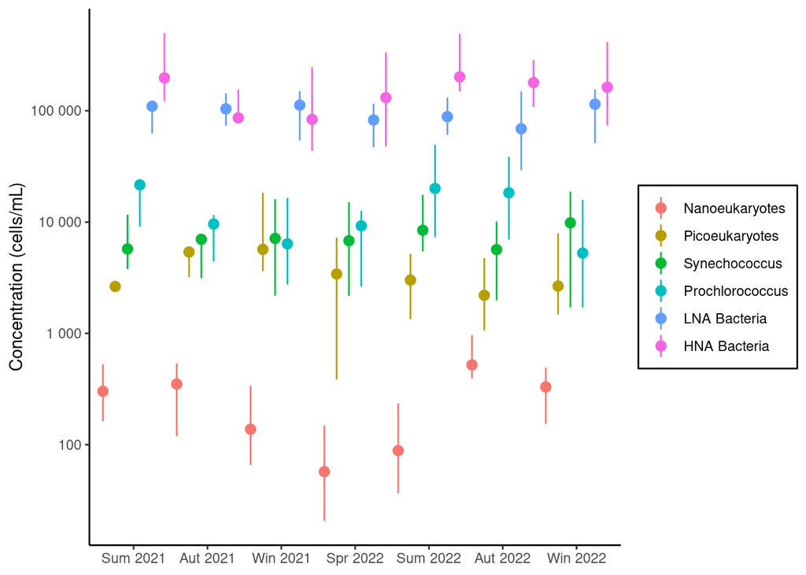

Figure 2: Median microplanktonic concentrations with min-max ranges across seasons. Vertical axis in logarithmic scale.